# Lecture 403

2021-09-11

## Support vector machines

## Recap

**Prev**: Artificial Neural Networks

- Logistic regression
- Artificial neural networks
- Deep learning

**Now**: Support vector machines

- Hyperplanes
- Linear separability
- Kernels

## Classification task

Can we learn to distinguish the two species from body mass and bill depth?

```r
penguins_to_learn <-
  palmerpenguins::penguins %>%
  dplyr::filter(
    species %in% c("Adelie", "Gentoo")
  ) %>%
  dplyr::mutate(
    species = forcats::fct_drop(species)
  ) %>%
  dplyr::filter(
    !is.na(body_mass_g)
    | !is.na(bill_depth_mm)
  ) %>%
  dplyr::mutate(dplyr::across(
      bill_length_mm:body_mass_g,
      scale
  ))

penguins_for_training <-
  penguins_to_learn %>%
  slice_sample(prop = 0.8)

penguins_for_testing <-
  penguins_to_learn %>%
  anti_join(penguins_for_training)
```

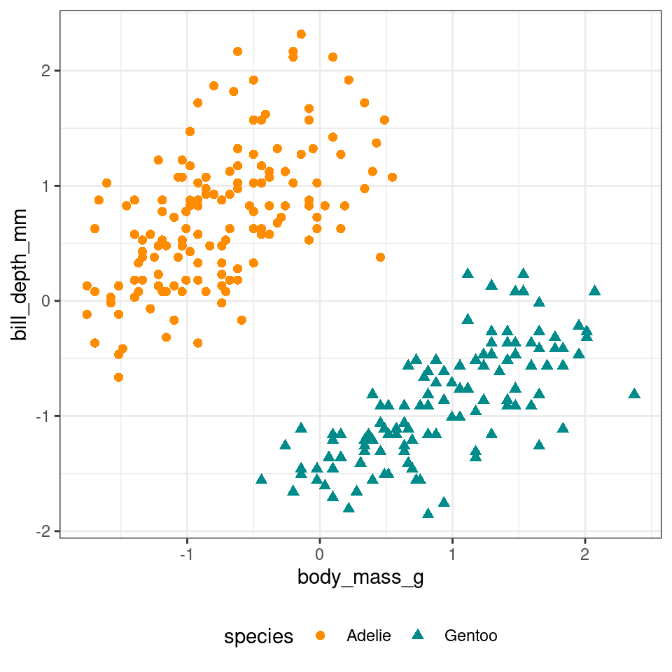

## Support vector machines

Supervised learning approach to classification

- a series of **input** values (predictors, independent variables)
- one **output** categorical value (outcome, dependent variable)

Partition of multidimensional space

- finding boundaries (*“hyperplanes”*)
- between homogenous groups of observations
- approach akin to
  - linear regression modelling
  - nearest neighbours approaches

## Nearest Neighbours (k-NN)

One of the simplest approaches to classification

Classification of a new observation:

- select `k` closest observations in multidimensional space
- new observation classified as most frequent class

```r
library(class)

species_3nn <- class::knn(
    train = penguins_for_training %>% dplyr::pull(body_mass_g, bill_depth_mm),
    test = penguins_for_testing %>% dplyr::pull(body_mass_g, bill_depth_mm),
    cl = penguins_for_training %>% dplyr::pull(species),
    k = 3
  )

penguins_for_testing <- penguins_for_testing %>%
  tibble::add_column(predicted_species_3nn = species_3nn)

caret::confusionMatrix(
  penguins_for_testing %>% dplyr::pull(predicted_species_3nn),
  penguins_for_testing %>% dplyr::pull(species)
)
```

## Performance

```
## Confusion Matrix and Statistics
##
##           Reference
## Prediction Adelie Gentoo
##     Adelie     25      4
##     Gentoo      3     23
##
##                Accuracy : 0.8727
##                  95% CI : (0.7552, 0.9473)
##     No Information Rate : 0.5091
##     P-Value [Acc > NIR] : 1.375e-08
##
##                   Kappa : 0.7452
##
##  Mcnemar's Test P-Value : 1
##
##             Sensitivity : 0.8929
##             Specificity : 0.8519
##          Pos Pred Value : 0.8621
##          Neg Pred Value : 0.8846
##              Prevalence : 0.5091
##          Detection Rate : 0.4545
##    Detection Prevalence : 0.5273
##       Balanced Accuracy : 0.8724
##
##        'Positive' Class : Adelie
##
```

## Hyperplanes

If a hyperplane can be drawn between classes

- e.g., a line in bi-dimensional space, a plane in three dimensions, etc
- classes are linearly separable

Find maximum-margin hyperplane

- line that maximises separation between classes
- conceptually similar to regression

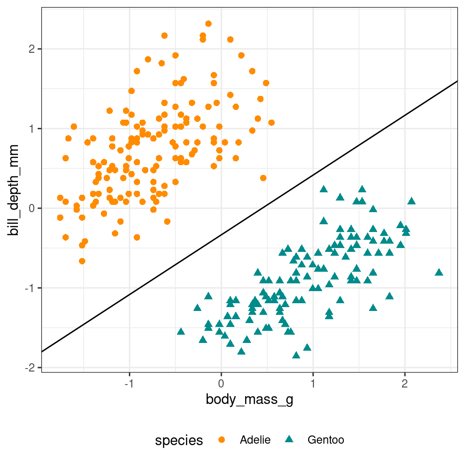

## e1071::svm

```r
library(e1071)

species_svm <- penguins_for_training %$%
  e1071::svm(
    species ~
      body_mass_g + bill_depth_mm,
    kernel = "linear",
    scale = FALSE
  )

penguins_for_testing <-
  penguins_for_testing %>%
  tibble::add_column(
    predicted_species_svn =
      stats::predict(
        species_svm,
        penguins_for_testing %>%
          dplyr::select(body_mass_g, bill_depth_mm)
      )
  )

caret::confusionMatrix(
  penguins_for_testing %>%
    dplyr::pull(predicted_species_svn),
  penguins_for_testing %>%
    dplyr::pull(species)
  )
```

## Performance

```
## Confusion Matrix and Statistics
##
##           Reference
## Prediction Adelie Gentoo
##     Adelie     28      0
##     Gentoo      0     27
##
##                Accuracy : 1
##                  95% CI : (0.9351, 1)
##     No Information Rate : 0.5091
##     P-Value [Acc > NIR] : < 2.2e-16
##
##                   Kappa : 1
##
##  Mcnemar's Test P-Value : NA
##
##             Sensitivity : 1.0000
##             Specificity : 1.0000
##          Pos Pred Value : 1.0000
##          Neg Pred Value : 1.0000
##              Prevalence : 0.5091
##          Detection Rate : 0.5091
##    Detection Prevalence : 0.5091
##       Balanced Accuracy : 1.0000
##
##        'Positive' Class : Adelie
##
```

## Not linearly separable

What if classes are *not* linearly separable?

- slack variable `C`
  - soft margin between classes
  - a *“cost”* is applied to cases beyond margins
- kernels *“trick”*
  - functions used to create additional dimensions
  - as functions of input values
    - linear, polinomial, sigmoids, Gaussian

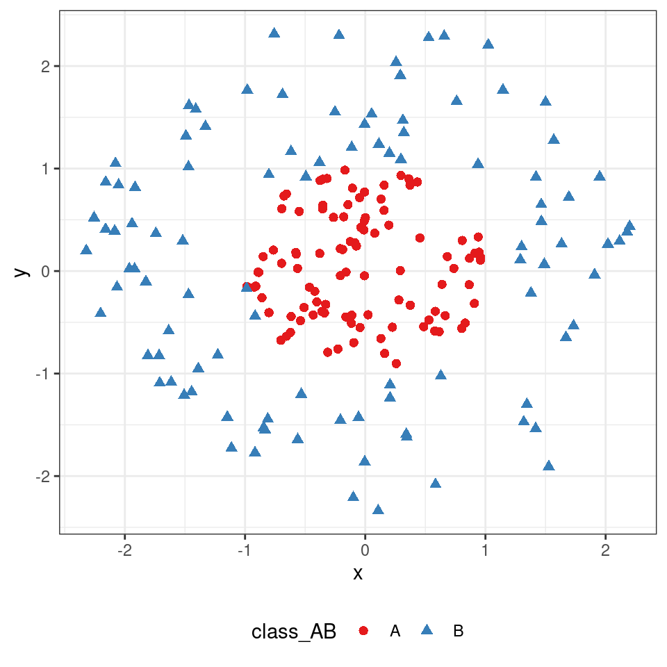

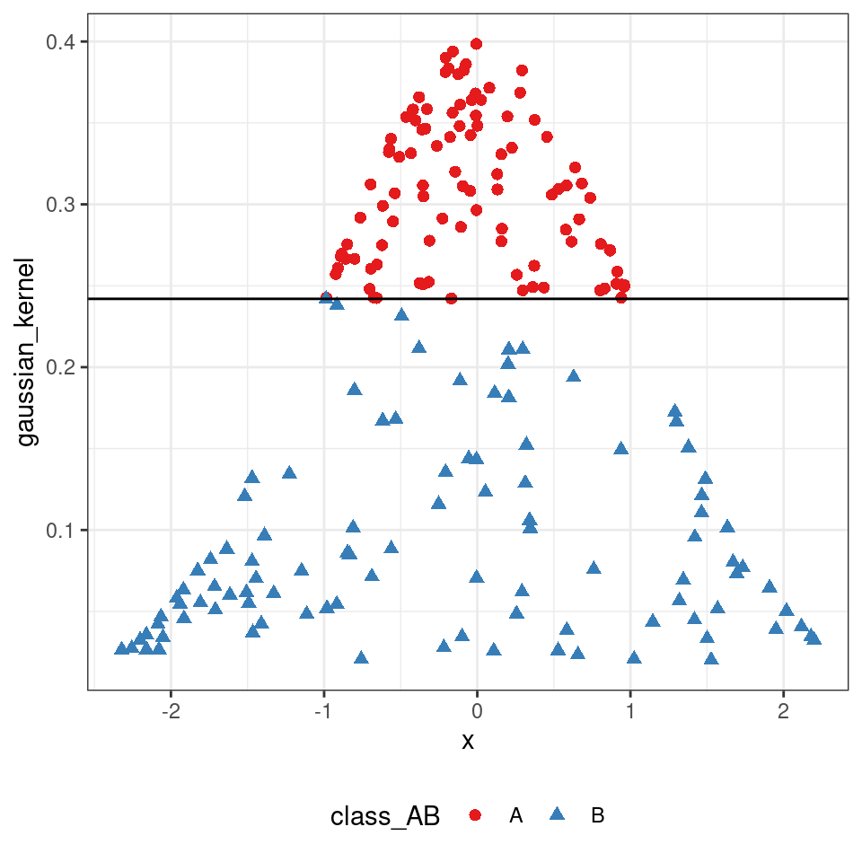

## e1071::svm

```r
class_AB_svm <-
  data_AB_for_training %$%
  e1071::svm(
    class_AB ~
      x + y,
    kernel = "linear",
    scale = FALSE
  )

data_AB_for_testing <-
  data_AB_for_testing %>%
  tibble::add_column(
    predicted_AB_svm =
      stats::predict(
        class_AB_svm,
        data_AB_for_testing %>%
          dplyr::select(x, y)
      )
  )

caret::confusionMatrix(
  data_AB_for_testing %>%
    dplyr::pull(predicted_AB_svm),
  data_AB_for_testing %>%
    dplyr::pull(class_AB)
  )
```

## Performance

```
## Confusion Matrix and Statistics
##
##           Reference
## Prediction  A  B
##          A 18 14
##          B  4  4
##
##                Accuracy : 0.55
##                  95% CI : (0.3849, 0.7074)
##     No Information Rate : 0.55
##     P-Value [Acc > NIR] : 0.56505
##
##                   Kappa : 0.0426
##
##  Mcnemar's Test P-Value : 0.03389
##
##             Sensitivity : 0.8182
##             Specificity : 0.2222
##          Pos Pred Value : 0.5625
##          Neg Pred Value : 0.5000
##              Prevalence : 0.5500
##          Detection Rate : 0.4500
##    Detection Prevalence : 0.8000
##       Balanced Accuracy : 0.5202
##
##        'Positive' Class : A
##
```

## e1071::svm

```r
class_AB_svm_radial <-
  data_AB_for_training %$%
  e1071::svm(
    class_AB ~ x + y,
    kernel = "radial",
    scale = FALSE,
    cost = 10
  )

data_AB_for_testing <-
  data_AB_for_testing %>%
  tibble::add_column(
    predicted_AB_svm_radial =
      stats::predict(
        class_AB_svm_radial,
        data_AB_for_testing %>%
          dplyr::select(x, y)
      )
  )

caret::confusionMatrix(
  data_AB_for_testing %>%
    dplyr::pull(predicted_AB_svm_radial),
  data_AB_for_testing %>%
    dplyr::pull(class_AB)
  )
```

## Performance

```
## Confusion Matrix and Statistics
##
##           Reference
## Prediction  A  B
##          A 22  1
##          B  0 17
##
##                Accuracy : 0.975
##                  95% CI : (0.8684, 0.9994)
##     No Information Rate : 0.55
##     P-Value [Acc > NIR] : 1.388e-09
##
##                   Kappa : 0.9492
##
##  Mcnemar's Test P-Value : 1
##
##             Sensitivity : 1.0000
##             Specificity : 0.9444
##          Pos Pred Value : 0.9565
##          Neg Pred Value : 1.0000
##              Prevalence : 0.5500
##          Detection Rate : 0.5500
##    Detection Prevalence : 0.5750
##       Balanced Accuracy : 0.9722
##
##        'Positive' Class : A
##
```

## Summary

Support vector machines

- Hyperplanes
- Linear separability
- Kernels

**Next**: Practical session

- Artificial neural networks
- Support vector machines